# Risk Factor Analysis

## Outcome Variable

**Outcome Variable:** wast_rec90d

## Predictor Variables

**Intervention Variable:** exclfeed6

**Adjustment Set:**

- arm
- sex
- W_mage
- meducyrs
- feducyrs
- hhwealth_quart
- hfoodsec
- W_mhtcm
- vagbrth
- W_gagebrth
- W_birthwt
- W_birthlen
- W_nrooms
- W_nchldlt5
- month
- brthmon
- W_parity
- impfloor
- impsan
- safeh20
- delta_W_mage
- delta_meducyrs
- delta_feducyrs
- delta_hhwealth_quart
- delta_hfoodsec
- delta_W_mhtcm
- delta_vagbrth
- delta_W_gagebrth
- delta_W_birthwt
- delta_W_birthlen
- delta_W_nrooms
- delta_W_nchldlt5
- delta_month
- delta_brthmon
- delta_W_parity
- delta_impfloor
- delta_impsan
- delta_safeh20

## Stratifying Variables

The analysis was stratified on these variable(s):

- agecat
- studyid
- country

## Data Summary

| agecat | studyid | country | exclfeed6 | wast_rec90d | n_cell | n |
| --- | --- | --- | --- | --- | --- | --- |
| 0-24 months | ki0047075b-MAL-ED | BANGLADESH | 0 | 0 | 28 | 121 |
| 0-24 months | ki0047075b-MAL-ED | BANGLADESH | 0 | 1 | 57 | 121 |
| 0-24 months | ki0047075b-MAL-ED | BANGLADESH | 1 | 0 | 16 | 121 |
| 0-24 months | ki0047075b-MAL-ED | BANGLADESH | 1 | 1 | 20 | 121 |
| 0-24 months | ki0047075b-MAL-ED | BRAZIL | 0 | 0 | 6 | 23 |
| 0-24 months | ki0047075b-MAL-ED | BRAZIL | 0 | 1 | 17 | 23 |
| 0-24 months | ki0047075b-MAL-ED | BRAZIL | 1 | 0 | 0 | 23 |
| 0-24 months | ki0047075b-MAL-ED | BRAZIL | 1 | 1 | 0 | 23 |
| 0-24 months | ki0047075b-MAL-ED | INDIA | 0 | 0 | 66 | 170 |
| 0-24 months | ki0047075b-MAL-ED | INDIA | 0 | 1 | 101 | 170 |
| 0-24 months | ki0047075b-MAL-ED | INDIA | 1 | 0 | 0 | 170 |
| 0-24 months | ki0047075b-MAL-ED | INDIA | 1 | 1 | 3 | 170 |
| 0-24 months | ki0047075b-MAL-ED | NEPAL | 0 | 0 | 18 | 90 |
| 0-24 months | ki0047075b-MAL-ED | NEPAL | 0 | 1 | 71 | 90 |
| 0-24 months | ki0047075b-MAL-ED | NEPAL | 1 | 0 | 0 | 90 |
| 0-24 months | ki0047075b-MAL-ED | NEPAL | 1 | 1 | 1 | 90 |
| 0-24 months | ki0047075b-MAL-ED | PERU | 0 | 0 | 5 | 29 |
| 0-24 months | ki0047075b-MAL-ED | PERU | 0 | 1 | 24 | 29 |
| 0-24 months | ki0047075b-MAL-ED | PERU | 1 | 0 | 0 | 29 |
| 0-24 months | ki0047075b-MAL-ED | PERU | 1 | 1 | 0 | 29 |
| 0-24 months | ki0047075b-MAL-ED | SOUTH AFRICA | 0 | 0 | 12 | 77 |
| 0-24 months | ki0047075b-MAL-ED | SOUTH AFRICA | 0 | 1 | 65 | 77 |
| 0-24 months | ki0047075b-MAL-ED | SOUTH AFRICA | 1 | 0 | 0 | 77 |
| 0-24 months | ki0047075b-MAL-ED | SOUTH AFRICA | 1 | 1 | 0 | 77 |
| 0-24 months | ki0047075b-MAL-ED | TANZANIA, UNITED REPUBLIC OF | 0 | 0 | 8 | 45 |
| 0-24 months | ki0047075b-MAL-ED | TANZANIA, UNITED REPUBLIC OF | 0 | 1 | 37 | 45 |
| 0-24 months | ki0047075b-MAL-ED | TANZANIA, UNITED REPUBLIC OF | 1 | 0 | 0 | 45 |
| 0-24 months | ki0047075b-MAL-ED | TANZANIA, UNITED REPUBLIC OF | 1 | 1 | 0 | 45 |
| 0-24 months | ki1000108-CMC-V-BCS-2002 | INDIA | 0 | 0 | 0 | 16 |
| 0-24 months | ki1000108-CMC-V-BCS-2002 | INDIA | 0 | 1 | 0 | 16 |

[output cut: 186 more lines]

The following strata were considered:

- agecat: 0-24 months, studyid: ki0047075b-MAL-ED, country: BANGLADESH
- agecat: 0-24 months, studyid: ki0047075b-MAL-ED, country: BRAZIL
- agecat: 0-24 months, studyid: ki0047075b-MAL-ED, country: INDIA
- agecat: 0-24 months, studyid: ki0047075b-MAL-ED, country: NEPAL
- agecat: 0-24 months, studyid: ki0047075b-MAL-ED, country: PERU
- agecat: 0-24 months, studyid: ki0047075b-MAL-ED, country: SOUTH AFRICA
- agecat: 0-24 months, studyid: ki0047075b-MAL-ED, country: TANZANIA, UNITED REPUBLIC OF
- agecat: 0-24 months, studyid: ki1000108-CMC-V-BCS-2002, country: INDIA
- agecat: 0-24 months, studyid: ki1000108-IRC, country: INDIA
- agecat: 0-24 months, studyid: ki1000109-EE, country: PAKISTAN
- agecat: 0-24 months, studyid: ki1000304b-SAS-CompFeed, country: INDIA
- agecat: 0-24 months, studyid: ki1000304b-SAS-FoodSuppl, country: INDIA
- agecat: 0-24 months, studyid: ki1017093b-PROVIDE, country: BANGLADESH
- agecat: 0-24 months, studyid: ki1101329-Keneba, country: GAMBIA
- agecat: 0-24 months, studyid: ki1113344-GMS-Nepal, country: NEPAL
- agecat: 0-24 months, studyid: ki1148112-LCNI-5, country: MALAWI
- agecat: 0-24 months, studyid: kiGH5241-JiVitA-3, country: BANGLADESH
- agecat: 0-24 months, studyid: kiGH5241-JiVitA-4, country: BANGLADESH
- agecat: 0-6 months, studyid: ki0047075b-MAL-ED, country: BANGLADESH
- agecat: 0-6 months, studyid: ki0047075b-MAL-ED, country: BRAZIL
- agecat: 0-6 months, studyid: ki0047075b-MAL-ED, country: INDIA
- agecat: 0-6 months, studyid: ki0047075b-MAL-ED, country: NEPAL
- agecat: 0-6 months, studyid: ki0047075b-MAL-ED, country: PERU
- agecat: 0-6 months, studyid: ki0047075b-MAL-ED, country: SOUTH AFRICA
- agecat: 0-6 months, studyid: ki0047075b-MAL-ED, country: TANZANIA, UNITED REPUBLIC OF
- agecat: 0-6 months, studyid: ki1000108-CMC-V-BCS-2002, country: INDIA
- agecat: 0-6 months, studyid: ki1000108-IRC, country: INDIA
- agecat: 0-6 months, studyid: ki1000109-EE, country: PAKISTAN
- agecat: 0-6 months, studyid: ki1000304b-SAS-CompFeed, country: INDIA
- agecat: 0-6 months, studyid: ki1000304b-SAS-FoodSuppl, country: INDIA
- agecat: 0-6 months, studyid: ki1017093b-PROVIDE, country: BANGLADESH
- agecat: 0-6 months, studyid: ki1101329-Keneba, country: GAMBIA
- agecat: 0-6 months, studyid: ki1113344-GMS-Nepal, country: NEPAL
- agecat: 0-6 months, studyid: ki1148112-LCNI-5, country: MALAWI
- agecat: 0-6 months, studyid: kiGH5241-JiVitA-3, country: BANGLADESH
- agecat: 0-6 months, studyid: kiGH5241-JiVitA-4, country: BANGLADESH
- agecat: 6-24 months, studyid: ki0047075b-MAL-ED, country: BANGLADESH
- agecat: 6-24 months, studyid: ki0047075b-MAL-ED, country: BRAZIL
- agecat: 6-24 months, studyid: ki0047075b-MAL-ED, country: INDIA
- agecat: 6-24 months, studyid: ki0047075b-MAL-ED, country: NEPAL
- agecat: 6-24 months, studyid: ki0047075b-MAL-ED, country: PERU
- agecat: 6-24 months, studyid: ki0047075b-MAL-ED, country: SOUTH AFRICA
- agecat: 6-24 months, studyid: ki0047075b-MAL-ED, country: TANZANIA, UNITED REPUBLIC OF
- agecat: 6-24 months, studyid: ki1000108-CMC-V-BCS-2002, country: INDIA
- agecat: 6-24 months, studyid: ki1000108-IRC, country: INDIA
- agecat: 6-24 months, studyid: ki1000109-EE, country: PAKISTAN
- agecat: 6-24 months, studyid: ki1000304b-SAS-CompFeed, country: INDIA
- agecat: 6-24 months, studyid: ki1000304b-SAS-FoodSuppl, country: INDIA
- agecat: 6-24 months, studyid: ki1017093b-PROVIDE, country: BANGLADESH
- agecat: 6-24 months, studyid: ki1101329-Keneba, country: GAMBIA
- agecat: 6-24 months, studyid: ki1113344-GMS-Nepal, country: NEPAL
- agecat: 6-24 months, studyid: ki1148112-LCNI-5, country: MALAWI
- agecat: 6-24 months, studyid: kiGH5241-JiVitA-3, country: BANGLADESH
- agecat: 6-24 months, studyid: kiGH5241-JiVitA-4, country: BANGLADESH

### Dropped Strata

Some strata were dropped due to rare outcomes:

- agecat: 0-24 months, studyid: ki0047075b-MAL-ED, country: BRAZIL
- agecat: 0-24 months, studyid: ki0047075b-MAL-ED, country: INDIA
- agecat: 0-24 months, studyid: ki0047075b-MAL-ED, country: NEPAL
- agecat: 0-24 months, studyid: ki0047075b-MAL-ED, country: PERU
- agecat: 0-24 months, studyid: ki0047075b-MAL-ED, country: SOUTH AFRICA
- agecat: 0-24 months, studyid: ki0047075b-MAL-ED, country: TANZANIA, UNITED REPUBLIC OF
- agecat: 0-24 months, studyid: ki1000108-CMC-V-BCS-2002, country: INDIA
- agecat: 0-24 months, studyid: ki1000108-IRC, country: INDIA
- agecat: 0-24 months, studyid: ki1000304b-SAS-FoodSuppl, country: INDIA
- agecat: 0-24 months, studyid: ki1148112-LCNI-5, country: MALAWI
- agecat: 0-6 months, studyid: ki0047075b-MAL-ED, country: BANGLADESH
- agecat: 0-6 months, studyid: ki0047075b-MAL-ED, country: BRAZIL
- agecat: 0-6 months, studyid: ki0047075b-MAL-ED, country: INDIA
- agecat: 0-6 months, studyid: ki0047075b-MAL-ED, country: NEPAL
- agecat: 0-6 months, studyid: ki0047075b-MAL-ED, country: PERU
- agecat: 0-6 months, studyid: ki0047075b-MAL-ED, country: SOUTH AFRICA
- agecat: 0-6 months, studyid: ki0047075b-MAL-ED, country: TANZANIA, UNITED REPUBLIC OF
- agecat: 0-6 months, studyid: ki1000108-CMC-V-BCS-2002, country: INDIA
- agecat: 0-6 months, studyid: ki1000108-IRC, country: INDIA
- agecat: 0-6 months, studyid: ki1000304b-SAS-CompFeed, country: INDIA
- agecat: 0-6 months, studyid: ki1000304b-SAS-FoodSuppl, country: INDIA
- agecat: 0-6 months, studyid: ki1148112-LCNI-5, country: MALAWI
- agecat: 6-24 months, studyid: ki0047075b-MAL-ED, country: BRAZIL
- agecat: 6-24 months, studyid: ki0047075b-MAL-ED, country: INDIA
- agecat: 6-24 months, studyid: ki0047075b-MAL-ED, country: NEPAL
- agecat: 6-24 months, studyid: ki0047075b-MAL-ED, country: PERU
- agecat: 6-24 months, studyid: ki0047075b-MAL-ED, country: SOUTH AFRICA
- agecat: 6-24 months, studyid: ki0047075b-MAL-ED, country: TANZANIA, UNITED REPUBLIC OF
- agecat: 6-24 months, studyid: ki1000108-CMC-V-BCS-2002, country: INDIA
- agecat: 6-24 months, studyid: ki1000108-IRC, country: INDIA
- agecat: 6-24 months, studyid: ki1000304b-SAS-CompFeed, country: INDIA
- agecat: 6-24 months, studyid: ki1000304b-SAS-FoodSuppl, country: INDIA
- agecat: 6-24 months, studyid: ki1148112-LCNI-5, country: MALAWI
- agecat: 6-24 months, studyid: kiGH5241-JiVitA-3, country: BANGLADESH

## Methods Detail

We’re interested in the causal parameters $E[Y_a]$ for all values of $a \in \mathcal{A}$. These parameters represent the mean outcome if, possibly contrary to fact, we intervened to set all units to have $A=a$. Under the randomization and positivity assumptions, these are identified by the statistical parameters $\psi_a=E_W[E_{Y|A,W}(Y|A=a,W)]$. In addition, we’re interested in the mean of $Y$, $E[Y]$ under no intervention (the observed mean). We will estimate these parameters by using SuperLearner to fit the relevant likelihood factors – $E_{Y|A,W}(Y|A=a,W)$ and $p(A=a|W)$, and then updating our likelihood fit using a joint TMLE.

For unadjusted analyses ($W=\{\}$), initial likelihoods were estimated using Lrnr_glm to estimate the simple $E(Y|A)$ and Lrnr_mean to estimate $p(A)$. For adjusted analyses, a small library containing Lrnr_glmnet, Lrnr_xgboost, and Lrnr_mean was used.

Having estimated these parameters, we will then use the delta method to estimate relative risks and attributable risks relative to a prespecified baseline level of $A$.

# Results Detail

## Results Plots

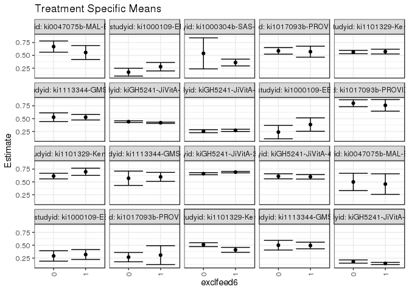

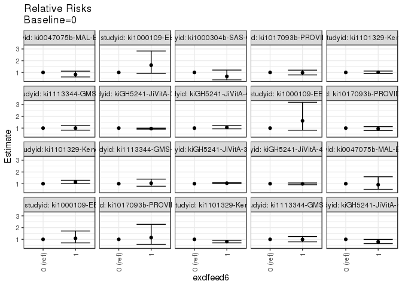

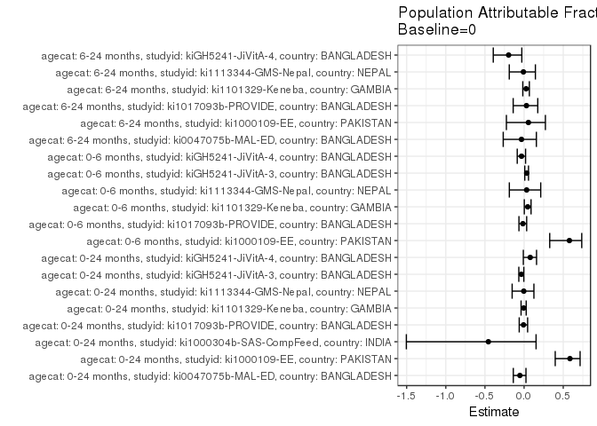

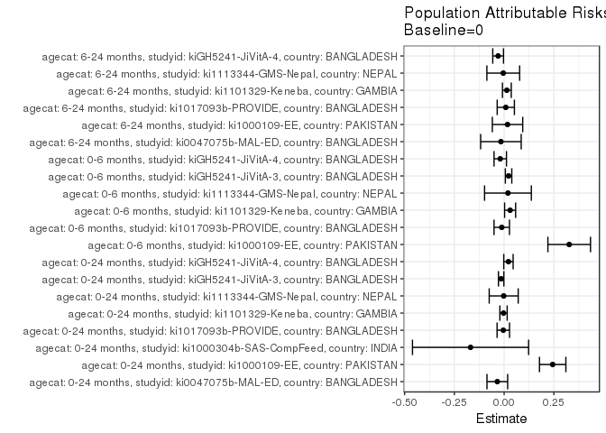

## Results Table

### Parameter: TSM

| agecat | studyid | country | intervention_level | baseline_level | estimate | ci_lower | ci_upper |
| --- | --- | --- | --- | --- | --- | --- | --- |
| 0-24 months | ki0047075b-MAL-ED | BANGLADESH | 0 | NA | 0.6705882 | 0.5617194 | 0.7794570 |
| 0-24 months | ki0047075b-MAL-ED | BANGLADESH | 1 | NA | 0.5555556 | 0.4202974 | 0.6908137 |
| 0-24 months | ki1000109-EE | PAKISTAN | 0 | NA | 0.1724152 | 0.0964138 | 0.2484166 |
| 0-24 months | ki1000109-EE | PAKISTAN | 1 | NA | 0.2795156 | 0.1967962 | 0.3622350 |
| 0-24 months | ki1000304b-SAS-CompFeed | INDIA | 0 | NA | 0.5384615 | 0.2364546 | 0.8404685 |
| 0-24 months | ki1000304b-SAS-CompFeed | INDIA | 1 | NA | 0.3600000 | 0.2937351 | 0.4262649 |
| 0-24 months | ki1017093b-PROVIDE | BANGLADESH | 0 | NA | 0.5872136 | 0.5235618 | 0.6508653 |
| 0-24 months | ki1017093b-PROVIDE | BANGLADESH | 1 | NA | 0.5712148 | 0.4640136 | 0.6784161 |
| 0-24 months | ki1101329-Keneba | GAMBIA | 0 | NA | 0.5640831 | 0.5309254 | 0.5972409 |
| 0-24 months | ki1101329-Keneba | GAMBIA | 1 | NA | 0.5733495 | 0.5271565 | 0.6195424 |
| 0-24 months | ki1113344-GMS-Nepal | NEPAL | 0 | NA | 0.5281296 | 0.4437315 | 0.6125278 |
| 0-24 months | ki1113344-GMS-Nepal | NEPAL | 1 | NA | 0.5273432 | 0.4738178 | 0.5808686 |
| 0-24 months | kiGH5241-JiVitA-3 | BANGLADESH | 0 | NA | 0.4411036 | 0.4241404 | 0.4580668 |
| 0-24 months | kiGH5241-JiVitA-3 | BANGLADESH | 1 | NA | 0.4204646 | 0.4082649 | 0.4326643 |
| 0-24 months | kiGH5241-JiVitA-4 | BANGLADESH | 0 | NA | 0.2549749 | 0.2258539 | 0.2840959 |
| 0-24 months | kiGH5241-JiVitA-4 | BANGLADESH | 1 | NA | 0.2711120 | 0.2483293 | 0.2938947 |
| 0-6 months | ki1000109-EE | PAKISTAN | 0 | NA | 0.2378796 | 0.1077400 | 0.3680191 |
| 0-6 months | ki1000109-EE | PAKISTAN | 1 | NA | 0.3852410 | 0.2547984 | 0.5156837 |
| 0-6 months | ki1017093b-PROVIDE | BANGLADESH | 0 | NA | 0.8000000 | 0.7319271 | 0.8680729 |
| 0-6 months | ki1017093b-PROVIDE | BANGLADESH | 1 | NA | 0.7592593 | 0.6464089 | 0.8721097 |
| 0-6 months | ki1101329-Keneba | GAMBIA | 0 | NA | 0.6141888 | 0.5595104 | 0.6688672 |
| 0-6 months | ki1101329-Keneba | GAMBIA | 1 | NA | 0.6977711 | 0.6278116 | 0.7677305 |
| 0-6 months | ki1113344-GMS-Nepal | NEPAL | 0 | NA | 0.5714286 | 0.4318973 | 0.7109598 |
| 0-6 months | ki1113344-GMS-Nepal | NEPAL | 1 | NA | 0.5983607 | 0.5108507 | 0.6858706 |
| 0-6 months | kiGH5241-JiVitA-3 | BANGLADESH | 0 | NA | 0.6604994 | 0.6401085 | 0.6808902 |
| 0-6 months | kiGH5241-JiVitA-3 | BANGLADESH | 1 | NA | 0.6911125 | 0.6763743 | 0.7058507 |
| 0-6 months | kiGH5241-JiVitA-4 | BANGLADESH | 0 | NA | 0.6094768 | 0.5602214 | 0.6587322 |
| 0-6 months | kiGH5241-JiVitA-4 | BANGLADESH | 1 | NA | 0.6006789 | 0.5558756 | 0.6454821 |
| 6-24 months | ki0047075b-MAL-ED | BANGLADESH | 0 | NA | 0.5000000 | 0.3311437 | 0.6688563 |
| 6-24 months | ki0047075b-MAL-ED | BANGLADESH | 1 | NA | 0.4583333 | 0.2582235 | 0.6584432 |
| 6-24 months | ki1000109-EE | PAKISTAN | 0 | NA | 0.2916168 | 0.1899649 | 0.3932687 |
| 6-24 months | ki1000109-EE | PAKISTAN | 1 | NA | 0.3185698 | 0.2226891 | 0.4144505 |
| 6-24 months | ki1017093b-PROVIDE | BANGLADESH | 0 | NA | 0.2680412 | 0.1773699 | 0.3587126 |
| 6-24 months | ki1017093b-PROVIDE | BANGLADESH | 1 | NA | 0.3076923 | 0.1243207 | 0.4910639 |
| 6-24 months | ki1101329-Keneba | GAMBIA | 0 | NA | 0.5111237 | 0.4730246 | 0.5492227 |
| 6-24 months | ki1101329-Keneba | GAMBIA | 1 | NA | 0.4103286 | 0.3621561 | 0.4585011 |
| 6-24 months | ki1113344-GMS-Nepal | NEPAL | 0 | NA | 0.5002542 | 0.4063545 | 0.5941539 |
| 6-24 months | ki1113344-GMS-Nepal | NEPAL | 1 | NA | 0.4948736 | 0.4308586 | 0.5588885 |
| 6-24 months | kiGH5241-JiVitA-4 | BANGLADESH | 0 | NA | 0.1822875 | 0.1510011 | 0.2135740 |
| 6-24 months | kiGH5241-JiVitA-4 | BANGLADESH | 1 | NA | 0.1448937 | 0.1241594 | 0.1656279 |

### Parameter: E(Y)

| agecat | studyid | country | intervention_level | baseline_level | estimate | ci_lower | ci_upper |
| --- | --- | --- | --- | --- | --- | --- | --- |
| 0-24 months | ki0047075b-MAL-ED | BANGLADESH | NA | NA | 0.6363636 | 0.5494154 | 0.7233119 |
| 0-24 months | ki1000109-EE | PAKISTAN | NA | NA | 0.4163424 | 0.3511349 | 0.4815500 |
| 0-24 months | ki1000304b-SAS-CompFeed | INDIA | NA | NA | 0.3697479 | 0.3045176 | 0.4349782 |
| 0-24 months | ki1017093b-PROVIDE | BANGLADESH | NA | NA | 0.5830619 | 0.5262762 | 0.6398476 |
| 0-24 months | ki1101329-Keneba | GAMBIA | NA | NA | 0.5610860 | 0.5320121 | 0.5901599 |
| 0-24 months | ki1113344-GMS-Nepal | NEPAL | NA | NA | 0.5260223 | 0.4802445 | 0.5718001 |
| 0-24 months | kiGH5241-JiVitA-3 | BANGLADESH | NA | NA | 0.4262098 | 0.4150208 | 0.4373989 |
| 0-24 months | kiGH5241-JiVitA-4 | BANGLADESH | NA | NA | 0.2766885 | 0.2556490 | 0.2977279 |
| 0-6 months | ki1000109-EE | PAKISTAN | NA | NA | 0.5648148 | 0.4692893 | 0.6603404 |
| 0-6 months | ki1017093b-PROVIDE | BANGLADESH | NA | NA | 0.7880435 | 0.7295878 | 0.8464992 |
| 0-6 months | ki1101329-Keneba | GAMBIA | NA | NA | 0.6442786 | 0.5973688 | 0.6911884 |
| 0-6 months | ki1113344-GMS-Nepal | NEPAL | NA | NA | 0.5906433 | 0.5164645 | 0.6648221 |
| 0-6 months | kiGH5241-JiVitA-3 | BANGLADESH | NA | NA | 0.6828279 | 0.6694976 | 0.6961581 |
| 0-6 months | kiGH5241-JiVitA-4 | BANGLADESH | NA | NA | 0.5900383 | 0.5478064 | 0.6322702 |
| 6-24 months | ki0047075b-MAL-ED | BANGLADESH | NA | NA | 0.4838710 | 0.3544124 | 0.6133295 |
| 6-24 months | ki1000109-EE | PAKISTAN | NA | NA | 0.3087248 | 0.2336906 | 0.3837591 |
| 6-24 months | ki1017093b-PROVIDE | BANGLADESH | NA | NA | 0.2764228 | 0.1950773 | 0.3577682 |
| 6-24 months | ki1101329-Keneba | GAMBIA | NA | NA | 0.5248918 | 0.4904236 | 0.5593599 |
| 6-24 months | ki1113344-GMS-Nepal | NEPAL | NA | NA | 0.4959128 | 0.4403572 | 0.5514684 |
| 6-24 months | kiGH5241-JiVitA-4 | BANGLADESH | NA | NA | 0.1522070 | 0.1331665 | 0.1712475 |

### Parameter: RR

| agecat | studyid | country | intervention_level | baseline_level | estimate | ci_lower | ci_upper |
| --- | --- | --- | --- | --- | --- | --- | --- |
| 0-24 months | ki0047075b-MAL-ED | BANGLADESH | 0 | 0 | 1.0000000 | 1.0000000 | 1.0000000 |
| 0-24 months | ki0047075b-MAL-ED | BANGLADESH | 1 | 0 | 0.8284600 | 0.6180708 | 1.1104651 |
| 0-24 months | ki1000109-EE | PAKISTAN | 0 | 0 | 1.0000000 | 1.0000000 | 1.0000000 |
| 0-24 months | ki1000109-EE | PAKISTAN | 1 | 0 | 1.6211775 | 0.9304114 | 2.8247897 |
| 0-24 months | ki1000304b-SAS-CompFeed | INDIA | 0 | 0 | 1.0000000 | 1.0000000 | 1.0000000 |
| 0-24 months | ki1000304b-SAS-CompFeed | INDIA | 1 | 0 | 0.6685714 | 0.3704954 | 1.2064597 |
| 0-24 months | ki1017093b-PROVIDE | BANGLADESH | 0 | 0 | 1.0000000 | 1.0000000 | 1.0000000 |
| 0-24 months | ki1017093b-PROVIDE | BANGLADESH | 1 | 0 | 0.9727548 | 0.7897962 | 1.1980964 |
| 0-24 months | ki1101329-Keneba | GAMBIA | 0 | 0 | 1.0000000 | 1.0000000 | 1.0000000 |
| 0-24 months | ki1101329-Keneba | GAMBIA | 1 | 0 | 1.0164273 | 0.9226521 | 1.1197334 |
| 0-24 months | ki1113344-GMS-Nepal | NEPAL | 0 | 0 | 1.0000000 | 1.0000000 | 1.0000000 |
| 0-24 months | ki1113344-GMS-Nepal | NEPAL | 1 | 0 | 0.9985109 | 0.8262236 | 1.2067243 |
| 0-24 months | kiGH5241-JiVitA-3 | BANGLADESH | 0 | 0 | 1.0000000 | 1.0000000 | 1.0000000 |
| 0-24 months | kiGH5241-JiVitA-3 | BANGLADESH | 1 | 0 | 0.9532106 | 0.9125982 | 0.9956304 |
| 0-24 months | kiGH5241-JiVitA-4 | BANGLADESH | 0 | 0 | 1.0000000 | 1.0000000 | 1.0000000 |
| 0-24 months | kiGH5241-JiVitA-4 | BANGLADESH | 1 | 0 | 1.0632890 | 0.9370588 | 1.2065236 |
| 0-6 months | ki1000109-EE | PAKISTAN | 0 | 0 | 1.0000000 | 1.0000000 | 1.0000000 |
| 0-6 months | ki1000109-EE | PAKISTAN | 1 | 0 | 1.6194793 | 0.8211617 | 3.1939058 |
| 0-6 months | ki1017093b-PROVIDE | BANGLADESH | 0 | 0 | 1.0000000 | 1.0000000 | 1.0000000 |
| 0-6 months | ki1017093b-PROVIDE | BANGLADESH | 1 | 0 | 0.9490741 | 0.7996836 | 1.1263725 |
| 0-6 months | ki1101329-Keneba | GAMBIA | 0 | 0 | 1.0000000 | 1.0000000 | 1.0000000 |
| 0-6 months | ki1101329-Keneba | GAMBIA | 1 | 0 | 1.1360856 | 0.9979922 | 1.2932873 |
| 0-6 months | ki1113344-GMS-Nepal | NEPAL | 0 | 0 | 1.0000000 | 1.0000000 | 1.0000000 |
| 0-6 months | ki1113344-GMS-Nepal | NEPAL | 1 | 0 | 1.0471311 | 0.7877525 | 1.3919138 |
| 0-6 months | kiGH5241-JiVitA-3 | BANGLADESH | 0 | 0 | 1.0000000 | 1.0000000 | 1.0000000 |
| 0-6 months | kiGH5241-JiVitA-3 | BANGLADESH | 1 | 0 | 1.0463485 | 1.0104768 | 1.0834936 |
| 0-6 months | kiGH5241-JiVitA-4 | BANGLADESH | 0 | 0 | 1.0000000 | 1.0000000 | 1.0000000 |
| 0-6 months | kiGH5241-JiVitA-4 | BANGLADESH | 1 | 0 | 0.9855648 | 0.9140218 | 1.0627075 |
| 6-24 months | ki0047075b-MAL-ED | BANGLADESH | 0 | 0 | 1.0000000 | 1.0000000 | 1.0000000 |
| 6-24 months | ki0047075b-MAL-ED | BANGLADESH | 1 | 0 | 0.9166667 | 0.5277052 | 1.5923241 |
| 6-24 months | ki1000109-EE | PAKISTAN | 0 | 0 | 1.0000000 | 1.0000000 | 1.0000000 |
| 6-24 months | ki1000109-EE | PAKISTAN | 1 | 0 | 1.0924261 | 0.6984048 | 1.7087436 |
| 6-24 months | ki1017093b-PROVIDE | BANGLADESH | 0 | 0 | 1.0000000 | 1.0000000 | 1.0000000 |
| 6-24 months | ki1017093b-PROVIDE | BANGLADESH | 1 | 0 | 1.1479290 | 0.5784531 | 2.2780429 |
| 6-24 months | ki1101329-Keneba | GAMBIA | 0 | 0 | 1.0000000 | 1.0000000 | 1.0000000 |
| 6-24 months | ki1101329-Keneba | GAMBIA | 1 | 0 | 0.8027971 | 0.7003739 | 0.9201989 |
| 6-24 months | ki1113344-GMS-Nepal | NEPAL | 0 | 0 | 1.0000000 | 1.0000000 | 1.0000000 |
| 6-24 months | ki1113344-GMS-Nepal | NEPAL | 1 | 0 | 0.9892442 | 0.7879985 | 1.2418857 |
| 6-24 months | kiGH5241-JiVitA-4 | BANGLADESH | 0 | 0 | 1.0000000 | 1.0000000 | 1.0000000 |
| 6-24 months | kiGH5241-JiVitA-4 | BANGLADESH | 1 | 0 | 0.7948634 | 0.6356887 | 0.9938951 |

### Parameter: PAR

| agecat | studyid | country | intervention_level | baseline_level | estimate | ci_lower | ci_upper |
| --- | --- | --- | --- | --- | --- | --- | --- |
| 0-24 months | ki0047075b-MAL-ED | BANGLADESH | 0 | NA | -0.0342246 | -0.0862150 | 0.0177658 |
| 0-24 months | ki1000109-EE | PAKISTAN | 0 | NA | 0.2439272 | 0.1776185 | 0.3102359 |
| 0-24 months | ki1000304b-SAS-CompFeed | INDIA | 0 | NA | -0.1687136 | -0.4604384 | 0.1230111 |
| 0-24 months | ki1017093b-PROVIDE | BANGLADESH | 0 | NA | -0.0041517 | -0.0353722 | 0.0270688 |
| 0-24 months | ki1101329-Keneba | GAMBIA | 0 | NA | -0.0029972 | -0.0213435 | 0.0153492 |
| 0-24 months | ki1113344-GMS-Nepal | NEPAL | 0 | NA | -0.0021073 | -0.0749528 | 0.0707382 |
| 0-24 months | kiGH5241-JiVitA-3 | BANGLADESH | 0 | NA | -0.0148938 | -0.0284572 | -0.0013303 |
| 0-24 months | kiGH5241-JiVitA-4 | BANGLADESH | 0 | NA | 0.0217136 | -0.0018084 | 0.0452355 |
| 0-6 months | ki1000109-EE | PAKISTAN | 0 | NA | 0.3269352 | 0.2198639 | 0.4340066 |
| 0-6 months | ki1017093b-PROVIDE | BANGLADESH | 0 | NA | -0.0119565 | -0.0506986 | 0.0267856 |
| 0-6 months | ki1101329-Keneba | GAMBIA | 0 | NA | 0.0300898 | 0.0024020 | 0.0577777 |
| 0-6 months | ki1113344-GMS-Nepal | NEPAL | 0 | NA | 0.0192147 | -0.0982832 | 0.1367127 |
| 0-6 months | kiGH5241-JiVitA-3 | BANGLADESH | 0 | NA | 0.0223285 | 0.0060891 | 0.0385679 |
| 0-6 months | kiGH5241-JiVitA-4 | BANGLADESH | 0 | NA | -0.0194385 | -0.0506485 | 0.0117715 |
| 6-24 months | ki0047075b-MAL-ED | BANGLADESH | 0 | NA | -0.0161290 | -0.1180103 | 0.0857522 |
| 6-24 months | ki1000109-EE | PAKISTAN | 0 | NA | 0.0171080 | -0.0592112 | 0.0934273 |
| 6-24 months | ki1017093b-PROVIDE | BANGLADESH | 0 | NA | 0.0083815 | -0.0348546 | 0.0516177 |
| 6-24 months | ki1101329-Keneba | GAMBIA | 0 | NA | 0.0137681 | -0.0083153 | 0.0358516 |
| 6-24 months | ki1113344-GMS-Nepal | NEPAL | 0 | NA | -0.0043414 | -0.0866558 | 0.0779730 |
| 6-24 months | kiGH5241-JiVitA-4 | BANGLADESH | 0 | NA | -0.0300805 | -0.0570592 | -0.0031018 |

### Parameter: PAF

| agecat | studyid | country | intervention_level | baseline_level | estimate | ci_lower | ci_upper |
| --- | --- | --- | --- | --- | --- | --- | --- |
| 0-24 months | ki0047075b-MAL-ED | BANGLADESH | 0 | NA | -0.0537815 | -0.1376866 | 0.0239355 |
| 0-24 months | ki1000109-EE | PAKISTAN | 0 | NA | 0.5858813 | 0.3976503 | 0.7152911 |
| 0-24 months | ki1000304b-SAS-CompFeed | INDIA | 0 | NA | -0.4562937 | -1.5037815 | 0.1529647 |
| 0-24 months | ki1017093b-PROVIDE | BANGLADESH | 0 | NA | -0.0071205 | -0.0621504 | 0.0450584 |
| 0-24 months | ki1101329-Keneba | GAMBIA | 0 | NA | -0.0053417 | -0.0386005 | 0.0268520 |
| 0-24 months | ki1113344-GMS-Nepal | NEPAL | 0 | NA | -0.0040061 | -0.1525124 | 0.1253644 |
| 0-24 months | kiGH5241-JiVitA-3 | BANGLADESH | 0 | NA | -0.0349447 | -0.0673427 | -0.0035300 |
| 0-24 months | kiGH5241-JiVitA-4 | BANGLADESH | 0 | NA | 0.0784765 | -0.0098297 | 0.1590607 |
| 0-6 months | ki1000109-EE | PAKISTAN | 0 | NA | 0.5788362 | 0.3273182 | 0.7363107 |
| 0-6 months | ki1017093b-PROVIDE | BANGLADESH | 0 | NA | -0.0151724 | -0.0656322 | 0.0328980 |
| 0-6 months | ki1101329-Keneba | GAMBIA | 0 | NA | 0.0467031 | 0.0025735 | 0.0888803 |
| 0-6 months | ki1113344-GMS-Nepal | NEPAL | 0 | NA | 0.0325318 | -0.1884274 | 0.2124091 |
| 0-6 months | kiGH5241-JiVitA-3 | BANGLADESH | 0 | NA | 0.0327000 | 0.0086527 | 0.0561640 |
| 0-6 months | kiGH5241-JiVitA-4 | BANGLADESH | 0 | NA | -0.0329445 | -0.0875834 | 0.0189495 |
| 6-24 months | ki0047075b-MAL-ED | BANGLADESH | 0 | NA | -0.0333333 | -0.2665360 | 0.1569306 |
| 6-24 months | ki1000109-EE | PAKISTAN | 0 | NA | 0.0554151 | -0.2259193 | 0.2721865 |
| 6-24 months | ki1017093b-PROVIDE | BANGLADESH | 0 | NA | 0.0303214 | -0.1393171 | 0.1747016 |
| 6-24 months | ki1101329-Keneba | GAMBIA | 0 | NA | 0.0262304 | -0.0165355 | 0.0671971 |
| 6-24 months | ki1113344-GMS-Nepal | NEPAL | 0 | NA | -0.0087544 | -0.1893124 | 0.1443918 |
| 6-24 months | kiGH5241-JiVitA-4 | BANGLADESH | 0 | NA | -0.1976290 | -0.3937262 | -0.0291227 |